# Harmonizing the 3D-CAM

Author

Doug Tommet

Published

October 26, 2023

# Data

The data for this harmonization analysis come from the Intuit and SAGES studies.

The SAGES study didn’t have the proper 3D-CAM. The CAM-S items in SAGES were transformed to approximate the 3D-CAM items.

## Item summaries

Table 1 shows the percent each of the 20 items was endorsed by study.

Table 1: Item summaries by study

| **Characteristic** | **Intuit**, N = 571<sup>1</sup> | **SAGES**, N = 2,175<sup>1</sup> |
| --- | --- | --- |
| 3DCAM 01 - What is the year? |  |  |
| 0. Error | 7 (1.2%) | 98 (4.6%) |
| 1. Correct | 562 (99%) | 2,012 (95%) |
| Unknown | 2 | 65 |
| 3DCAM 02 - What is the day of the week? |  |  |
| 0. Error | 35 (6.1%) | 222 (11%) |
| 1. Correct | 535 (94%) | 1,887 (89%) |
| Unknown | 1 | 66 |
| 3DCAM 03 - What type of place is this |  |  |
| 0. Error | 4 (0.7%) | 128 (6.1%) |
| 1. Correct | 565 (99%) | 1,984 (94%) |
| Unknown | 2 | 63 |
| 3DCAM 04 - Digit Span Backwards - 3 |  |  |
| 0. Correct | 513 (90%) | 1,817 (87%) |
| 1. Error | 57 (10%) | 272 (13%) |
| Unknown | 1 | 86 |
| 3DCAM 05 - Digit Span Backwards - 4 |  |  |
| 0. Correct | 382 (67%) | 1,168 (56%) |
| 1. Error | 188 (33%) | 919 (44%) |
| Unknown | 1 | 88 |
| 3DCAM 06 - Days of Week Backwards |  |  |
| 0. All correct | 544 (95%) | 1,955 (92%) |
| 1. Any error | 26 (4.6%) | 159 (7.5%) |
| Unknown | 1 | 61 |
| 3DCAM 07 - Months of Year Backwards |  |  |
| 0. All correct | 468 (82%) | 1,537 (73%) |
| 1. Any error | 102 (18%) | 574 (27%) |
| Unknown | 1 | 64 |
| 3DCAM 08 - Have you felt confused at any time during the last day? |  |  |
| 0. No | 495 (87%) | 1,694 (82%) |
| 1. Yes | 74 (13%) | 360 (18%) |
| Unknown | 2 | 121 |
| 3DCAM 09 - During the past day, did you think that you were not really here (in the hospital)? |  |  |
| 0. No | 558 (98%) | 1,883 (92%) |
| 1. Yes | 11 (1.9%) | 171 (8.3%) |
| Unknown | 2 | 121 |
| 3DCAM 10 - During the past day, did you see things that were not really there? |  |  |
| 0. No | 551 (97%) | 1,892 (93%) |
| 1. Yes | 18 (3.2%) | 153 (7.5%) |
| Unknown | 2 | 130 |
| 3DCAM 11 - Was the patient sleepy, stuporous, or comatose during the interview |  |  |
| 0. No | 560 (98%) | 1,988 (94%) |
| 1. Yes | 10 (1.8%) | 124 (5.9%) |
| Unknown | 1 | 63 |
| 3DCAM 12 - Did the patient show hypervigilance such as excessively strong responses to ordinary stimuli in the environment? |  |  |
| 0. No | 570 (100%) | 2,109 (100%) |
| 1. Yes | 0 (0%) | 3 (0.1%) |
| Unknown | 1 | 63 |
| 3DCAM 13 - Was the patient's flow of ideas unclear or illogical, unrelated to the interview or making contradictory statements? |  |  |
| 0. No | 567 (99%) | 1,881 (90%) |
| 1. Yes | 3 (0.5%) | 213 (10%) |
| Unknown | 1 | 81 |
| 3DCAM 14 - Conversation rambling, for example, did the patient give inappropriately verbose and off target responses? |  |  |
| 0. No | 565 (99%) | 0 (NA%) |
| 1. Yes | 5 (0.9%) | 0 (NA%) |
| Unknown | 1 | 2,175 |
| 3DCAM 15 - Was the patient's speech unusually stuporous, limited, or sparse? |  |  |
| 0. No | 562 (99%) | 0 (NA%) |
| 1. Yes | 8 (1.4%) | 0 (NA%) |
| Unknown | 1 | 2,175 |
| 3DCAM 16 - Did the patient have trouble keeping track of what was being said during the interview? |  |  |
| 0. No | 554 (97%) | 1,357 (65%) |
| 1. Yes | 16 (2.8%) | 745 (35%) |
| Unknown | 1 | 73 |
| 3DCAM 17 - Did the patient fail to attend to the interview due to being inappropriately distracted by environmental stimuli? |  |  |
| 0. No | 569 (100%) | 0 (NA%) |
| 1. Yes | 1 (0.2%) | 0 (NA%) |
| Unknown | 1 | 2,175 |
| 3DCAM 18 - Did the patient's level of consciousness fluctuate during the interview? |  |  |
| 0. No | 566 (99%) | 2,075 (98%) |
| 1. Yes | 4 (0.7%) | 36 (1.7%) |
| Unknown | 1 | 64 |
| 3DCAM 19 - Did the patient's level of attention fluctuate during the interview? |  |  |
| 0. No | 558 (98%) | 1,949 (93%) |
| 1. Yes | 10 (1.8%) | 141 (6.7%) |
| Unknown | 3 | 85 |
| 3DCAM 20 - Did the patient's speech/thinking fluctuate during the interview? |  |  |
| 0. No | 569 (100%) | 2,048 (98%) |
| 1. Yes | 1 (0.2%) | 42 (2.0%) |
| Unknown | 1 | 85 |

<sup>1</sup> n (%)

# Harmonizing the 3D-CAM severity scores

The harmonization process consisted of several steps.

1. Fit a CFA model in the SAGES data
2. Fix the item parameters for items 1, 2, 3, 4, 5, 6, 7, and 9 to what was estimated in SAGES
3. Fit a CFA model in Intuit with paramters for items 1, 2, 3, 4, 5, 6, 7, and 9 fixed and the rest freely estimated.
4. Fix all item parameters to estimated values, mean =0, variance = 1, and fit a CFA model to get the factor scores.

## Factor loadings (standardized)

Table 2 shows the standardized factor loadings from SAGES. This is from step 1 in the list above.

**Note**

The following items have low factor loadings in the Intuit study:

- 3D-CAM 08 - Have you felt confused at any time during the last day?
- 3D-CAM 10 - During the past day, did you see things that were not really there?

Table 2: Standardized factor loadings by study

| label | SAGES | Intuit |
| --- | --- | --- |
| 3DCAM 01 - What is the year? (reverse coded) | 0.812 | 0.812 |
| 3DCAM 02 - What is the day of the week? (reverse coded) | 0.685 | 0.685 |
| 3DCAM 03 - What type of place is this? (reverse coded) | 0.814 | 0.814 |
| 3DCAM 04 - Digit Span Backwards - 3 | 0.763 | 0.763 |
| 3DCAM 05 - Digit Span Backwards - 4 | 0.651 | 0.651 |
| 3DCAM 06 - Days of Week Backwards | 0.819 | 0.819 |
| 3DCAM 07 - Months of Year Backwards | 0.736 | 0.735 |
| 3DCAM 08 - Have you felt confused at any time during the last day? | 0.523 | 0.067 |
| 3DCAM 09 - During the past day, did you think that you were not really here (in the hospital)? | 0.499 | 0.498 |
| 3DCAM 10 - During the past day, did you see things that were not really there? | 0.492 | 0.165 |
| 3DCAM 11 - Was the patient sleepy, stuporous, or comatose during the interview | 0.755 | 0.876 |
| 3DCAM 12 - Did the patient show hypervigilance such as excessively strong responses to ordinary stimuli in the environment? | 0.635 | NA |
| 3DCAM 13 - Was the patient's flow of ideas unclear or illogical, unrelated to the interview or making contradictory statements? | 0.764 | 0.957 |
| 3DCAM 14 - Conversation rambling, for example, did the patient give inappropriately verbose and off target responses? | NA | 0.875 |
| 3DCAM 15 - Was the patient's speech unusually stuporous, limited, or sparse? | NA | 0.942 |
| 3DCAM 16 - Did the patient have trouble keeping track of what was being said during the interview? | 0.893 | 0.984 |
| 3DCAM 17 - Did the patient fail to attend to the interview due to being inappropriately distracted by environmental stimuli? | NA | 0.623 |
| 3DCAM 18 - Did the patient's level of consciousness fluctuate during the interview? | 0.684 | 0.863 |
| 3DCAM 19 - Did the patient's level of attention fluctuate during the interview? | 0.732 | 0.882 |
| 3DCAM 20 - Did the patient's speech/thinking fluctuate during the interview? | 0.784 | 0.723 |

Table 3: Unstandardized factor loading by study

| label | SAGES | Intuit |
| --- | --- | --- |
| 3DCAM 01 - What is the year? (reverse coded) | 2.526 | 2.526 |
| 3DCAM 02 - What is the day of the week? (reverse coded) | 1.704 | 1.704 |
| 3DCAM 03 - What type of place is this? (reverse coded) | 2.540 | 2.540 |
| 3DCAM 04 - Digit Span Backwards - 3 | 2.143 | 2.143 |
| 3DCAM 05 - Digit Span Backwards - 4 | 1.555 | 1.555 |
| 3DCAM 06 - Days of Week Backwards | 2.587 | 2.587 |
| 3DCAM 07 - Months of Year Backwards | 1.969 | 1.969 |
| 3DCAM 08 - Have you felt confused at any time during the last day? | 1.112 | 0.122 |
| 3DCAM 09 - During the past day, did you think that you were not really here (in the hospital)? | 1.043 | 1.043 |
| 3DCAM 10 - During the past day, did you see things that were not really there? | 1.024 | 0.303 |
| 3DCAM 11 - Was the patient sleepy, stuporous, or comatose during the interview | 2.087 | 3.298 |
| 3DCAM 12 - Did the patient show hypervigilance such as excessively strong responses to ordinary stimuli in the environment? | 1.490 | NA |
| 3DCAM 13 - Was the patient's flow of ideas unclear or illogical, unrelated to the interview or making contradictory statements? | 2.147 | 6.012 |
| 3DCAM 14 - Conversation rambling, for example, did the patient give inappropriately verbose and off target responses? | NA | 3.271 |
| 3DCAM 15 - Was the patient's speech unusually stuporous, limited, or sparse? | NA | 5.068 |
| 3DCAM 16 - Did the patient have trouble keeping track of what was being said during the interview? | 3.591 | 10.044 |
| 3DCAM 17 - Did the patient fail to attend to the interview due to being inappropriately distracted by environmental stimuli? | NA | 1.445 |
| 3DCAM 18 - Did the patient's level of consciousness fluctuate during the interview? | 1.702 | 3.097 |
| 3DCAM 19 - Did the patient's level of attention fluctuate during the interview? | 1.949 | 3.399 |
| 3DCAM 20 - Did the patient's speech/thinking fluctuate during the interview? | 2.290 | 1.899 |

## Test Information

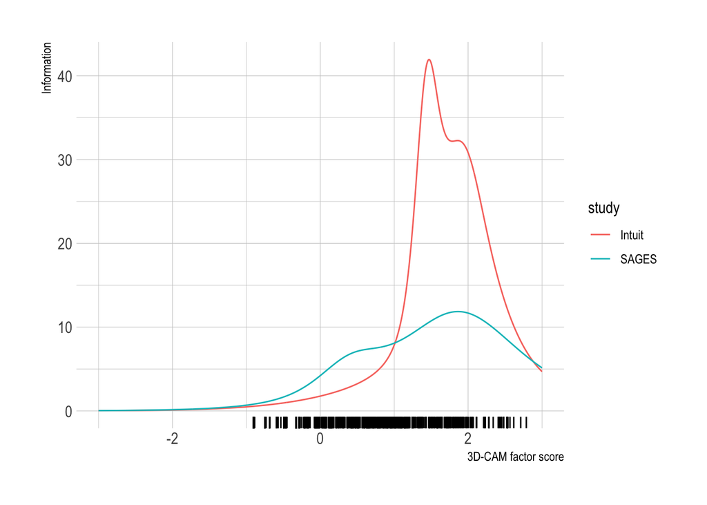

Figure 1: Test Information curve of 3D-CAM in Intuit and SAGES

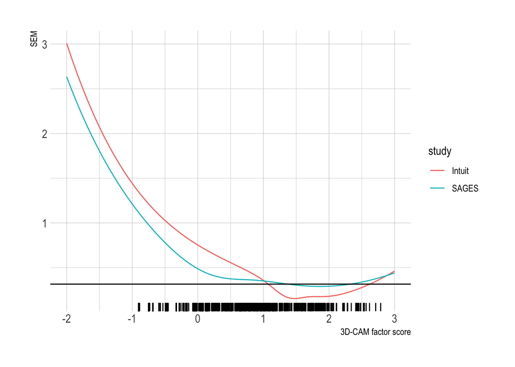

Figure 2: Standard error mesaurement curve of 3D-CAM in Intuit and SAGES

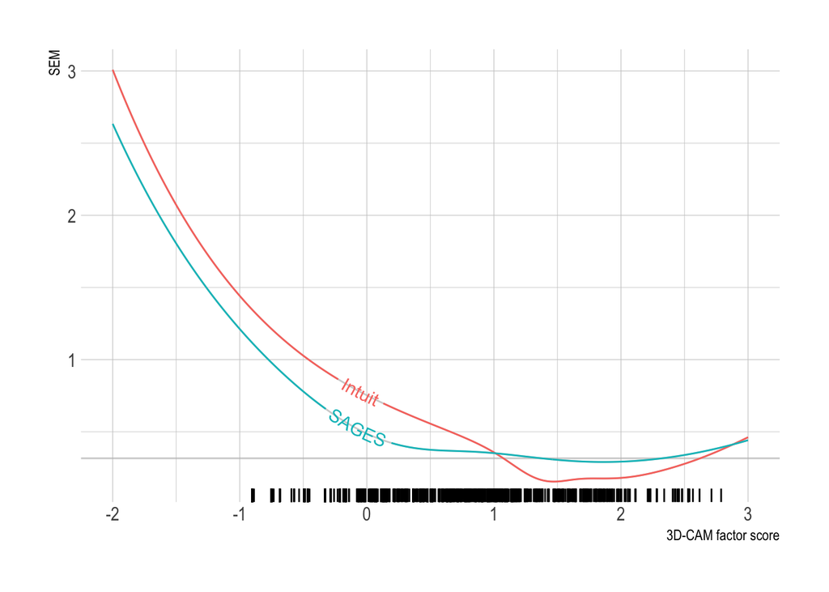

Figure 3: Standard error mesaurement curve of 3D-CAM in Intuit and SAGES

## Factor score summary

Table 4: Descriptive statistics of harmonized 3D-CAM severity factor score

| **Characteristic** | **Intuit**, N = 571 | **SAGES**, N = 2,175 |
| --- | --- | --- |
| F |  |  |
| N | 570 | 2,122 |
| Mean (SD) | -0.23 (0.63) | 0.00 (0.85) |
| Median (IQR) | -0.69 (-0.75, 0.07) | -0.21 (-0.90, 0.63) |
| Range | -0.75, 1.99 | -0.90, 2.79 |
| Unknown | 1 | 53 |

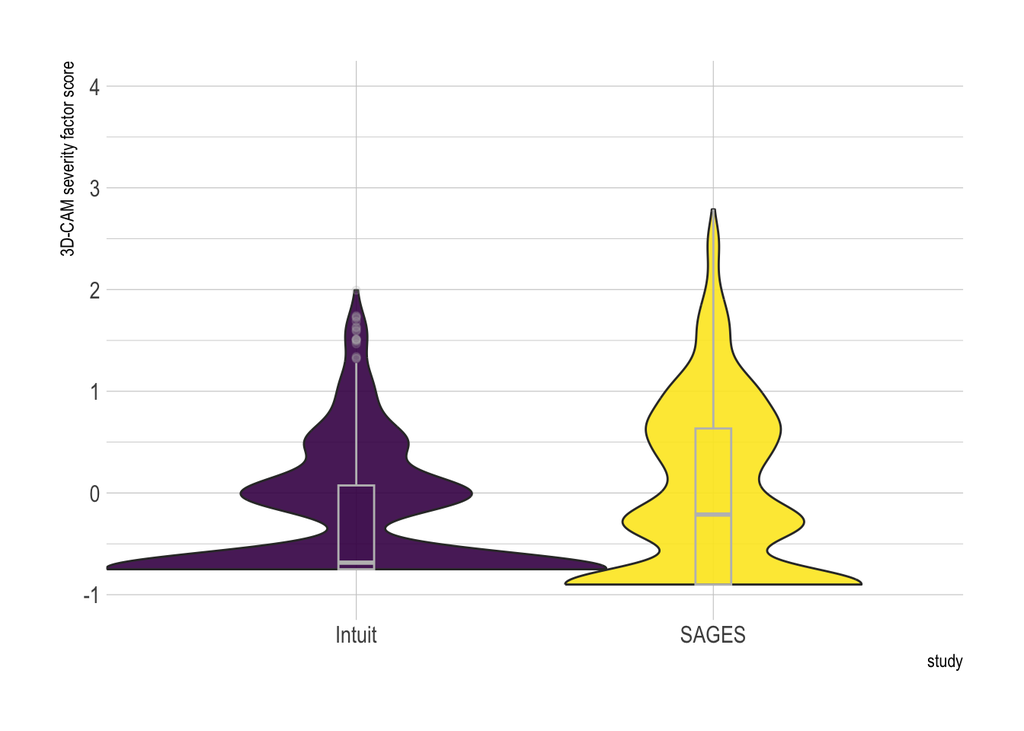

Figure 4: Distribution of harmonized factor scores

# Convert factor score scale to 3D-CAM-S score scale

The latent factor score is on a N(0, 1) scale. To aid interpretation, we will transform it to the original 3D-CAM severity scale. This is the process:

1. In the Intuit study, regress the 3D-CAM score on the factor score using restricted cubic splines.
2. Use the model to get predicted #D-CAM scores using the factor scores from SAGES. Predicted values less that 0 will be rounded up to 0.
3. The new 3D-CAM severity score will be the original 3D-CAM score in Intuit, and the predicted score in SAGES.

## Factor score and 3D-CAM-S score in Intuit

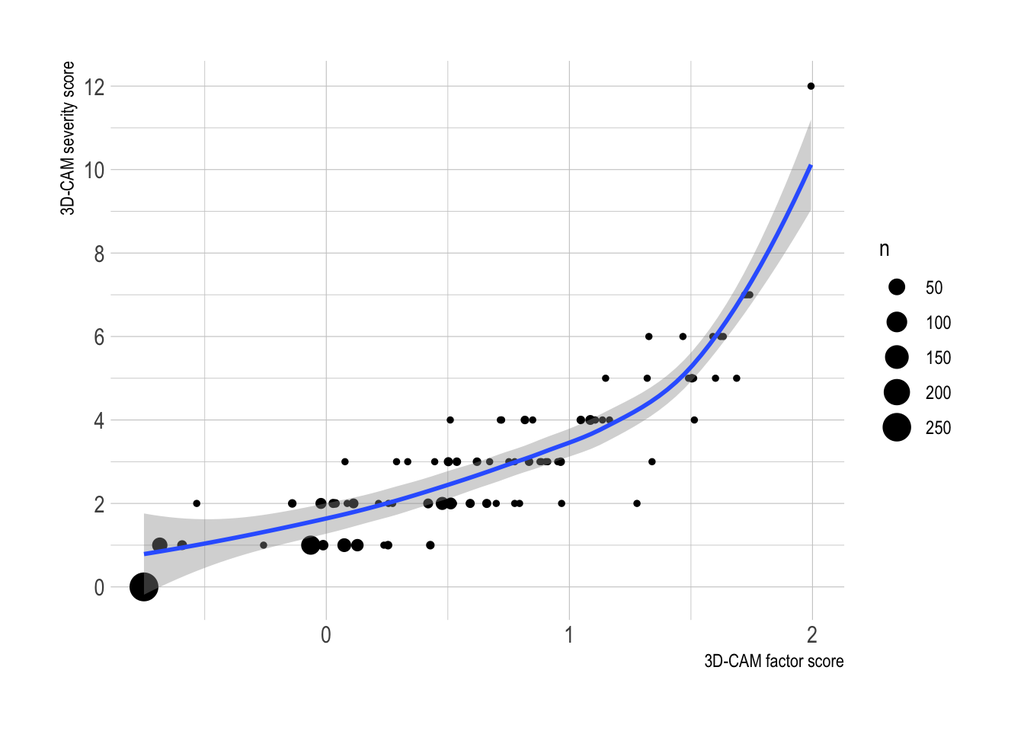

Figure 5: Relationship between severity score and factor score in Intuit

## 3D-CAM-S score: Observed vs Predicted

### Intuit

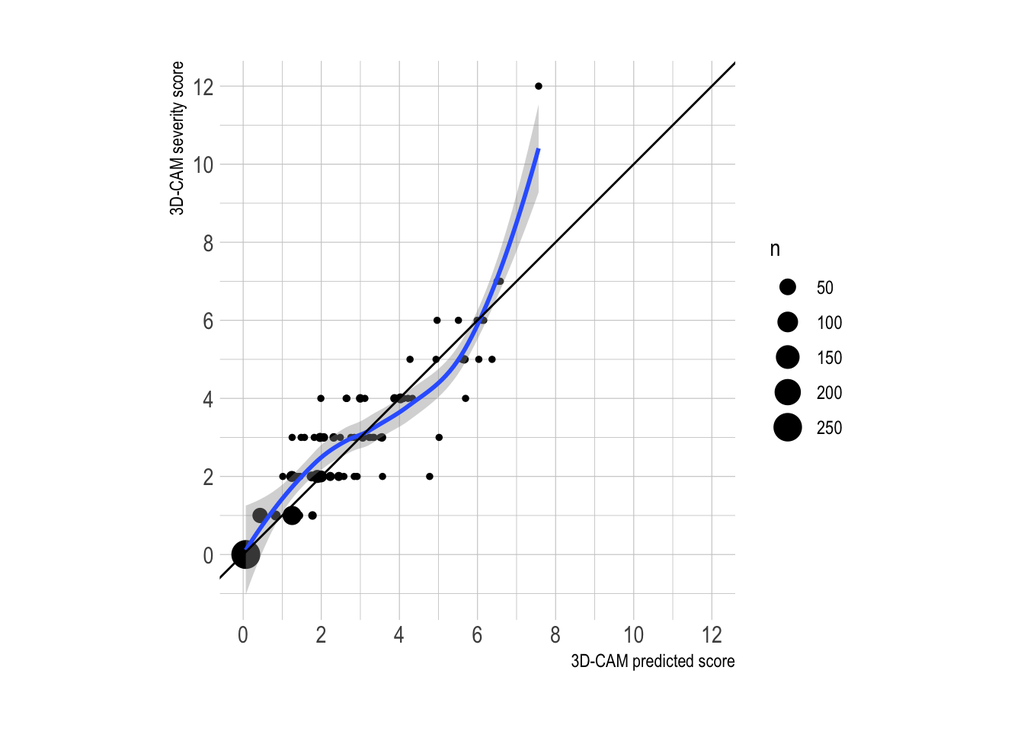

Figure 6: Relationship between observed and predicted severity scores in Intuit

### SAGES

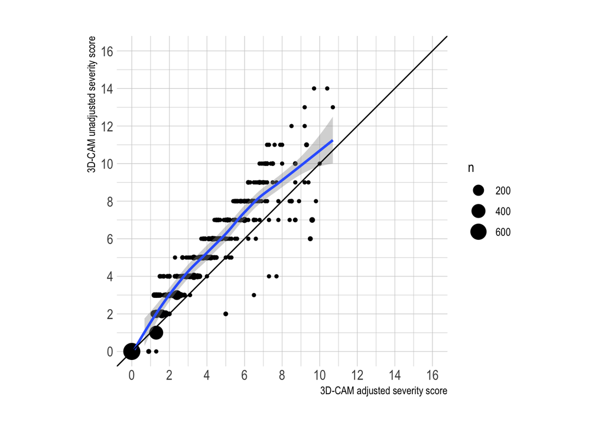

Figure 7: Relationship between unadjusted and adjusted severity scores in SAGES

## 3D-CAM-S score summary

Table 5: Descriptive statistics of predicted 3D-CAM severity score

| **Characteristic** | **Intuit**, N = 571 | **SAGES**, N = 2,175 |
| --- | --- | --- |
| pred_3dcam |  |  |
| N | 570 | 2,122 |
| Mean (SD) | 1.04 (1.30) | 1.72 (1.94) |
| Median (IQR) | 0.40 (0.10, 1.30) | 1.30 (0.00, 2.40) |
| Range | 0.10, 7.60 | 0.00, 10.70 |
| Unknown | 1 | 53 |

Table 6: Descriptive statistics of observed 3D-CAM severity score in Intuit

| **Characteristic** | **N = 571** |
| --- | --- |
| dcam_score |  |
| N | 571 |
| Mean (SD) | 1.02 (1.38) |
| Median (IQR) | 1.00 (0.00, 1.00) |
| Range | 0.00, 12.00 |

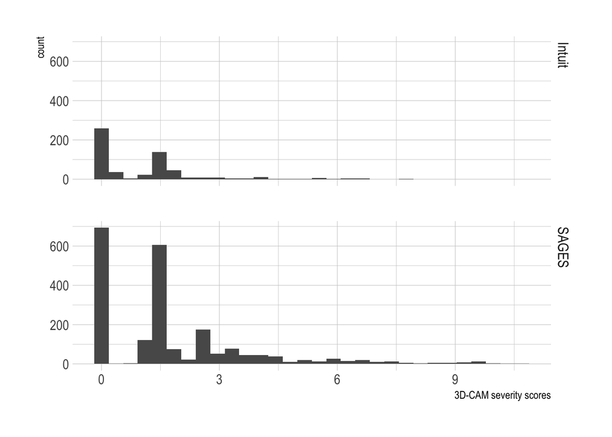

Figure 8: Distribution of predicted 3D-CAM severity scores

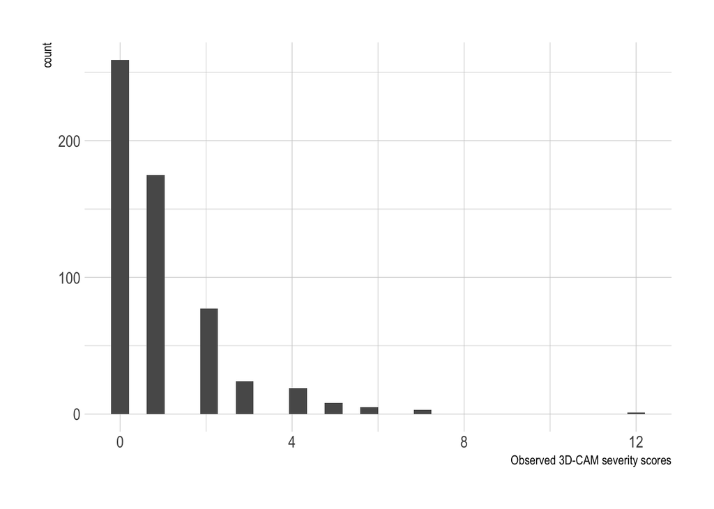

This is the prevalence of 3D-CAM scores greater than or equal to 3.

Table 7: Crosstab of 3D-CAM severity score greater than or equal to 3 by study

|  | study Intuit | study SAGES | Total |  |
| --- | --- | --- | --- | --- |
| 3D-CAM >= 3 |  |  |  |  |
| FALSE | 511 (89%) | 1,724 (79%) | 2,235 (81%) |  |
| TRUE | 60 (11%) | 398 (18%) | 458 (17%) |  |
| Unknown | 0 (0%) | 53 (2.4%) | 53 (1.9%) |  |
| Total | 571 (100%) | 2,175 (100%) | 2,746 (100%) |  |

This is how the 3D-CAM score greater than or equal to 3 compares to the SAGES CAM delirium.

Table 8: Crosstab of 3D-CAM severity score greater than or equal to 3 by CAM delirium

|  | vdcamdelirium 0 | vdcamdelirium 1 | Total |  |
| --- | --- | --- | --- | --- |
| 3D-CAM >= 3 |  |  |  |  |
| FALSE | 1,709 (87%) | 15 (7.1%) | 1,724 (79%) |  |
| TRUE | 201 (10%) | 197 (93%) | 398 (18%) |  |
| Unknown | 53 (2.7%) | 0 (0%) | 53 (2.4%) |  |
| Total | 1,963 (100%) | 212 (100%) | 2,175 (100%) |  |

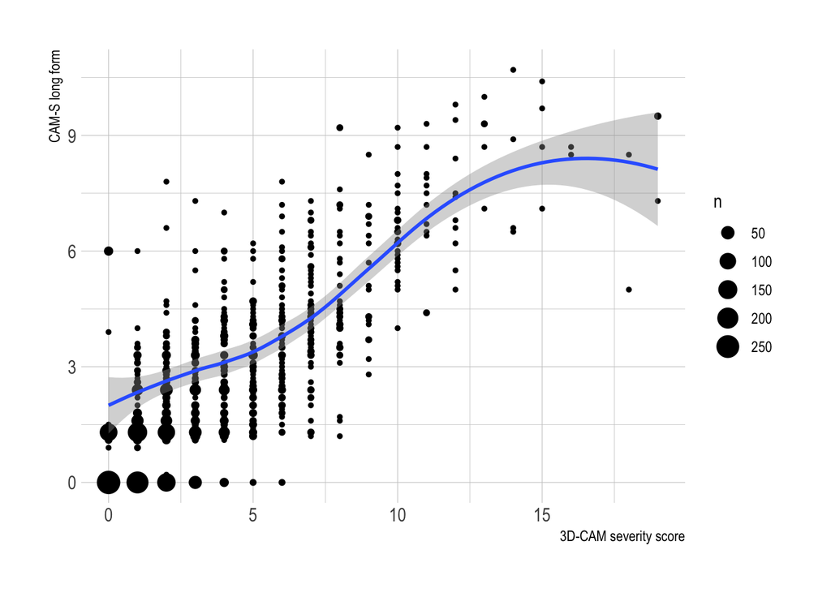

Figure 10: Association of 3D-CAM severity scores with CAM-S long-form

The correlation between the CAM-S long-form and 3D-CAM score in SAGES is 0.77.

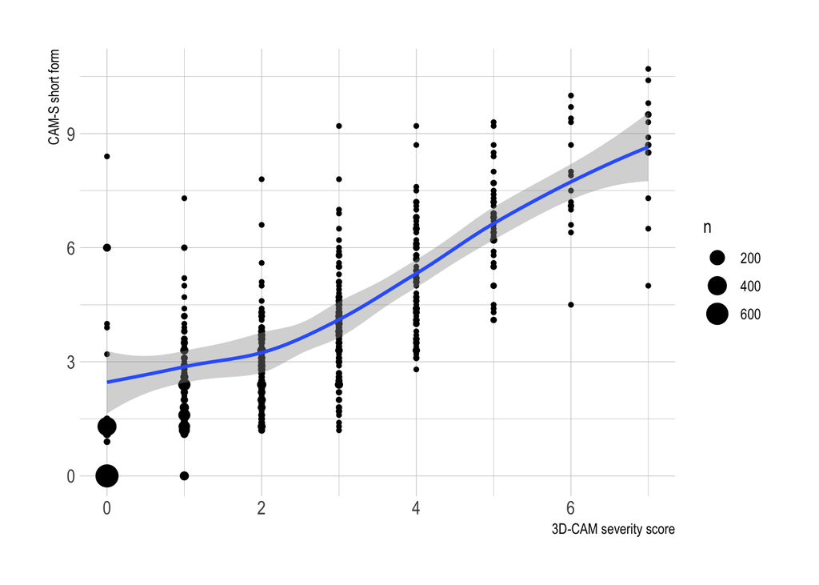

Figure 11: Association of 3D-CAM severity scores with CAM-S short-form

The correlation between the CAM-S short-form and 3D-CAM score in SAGES is 0.85.